## Two Sample t-test with Equal Variances ( Manually )

Two sample t-test is used to check if there is a difference between one quantitative variable from each of the two groups.

> *Question: Stability of the beer foam influences the overall perceived quality of a beer. It can be measured by a variable called tau which tells the half-life of the foam stand on top of the poured beer.* *So for this, let us determine: Is there a difference between the foam stand of a particular beer if it’s poured at room temparature versus poured cold?*
- Step 0: Check your assumptions
- Step 1: Set Null and alternate hypothesis
- Step 2: Choose alpha, Level of Significance
- Step 3: Calcualte the Test Statistic
- Step 4: Draw a picture
- Step 5: Find the p-value
- Step 6: Is the p-value < $\alpha$ ? If so, Reject the Null
- Step 7: Also Compute a Confidence Interval to DoubleCheck

##### Step 0: Assumptions

- Random Sample
- Observations are Independent
- Sample is less than 10% of the entire population size
- Differences are nearly normal or the Sample size is atleast more than 30.
- If the sample differences aren’t normally distributed or when we have rank-ordered data instead of continuous quantitative data, we can choose **nonparametric alternative** for Two sample t-test with equal variance : **Wilcoxon Two Sample Signed Rank test**
- For two-sample t-test, we need to check the variance across the group.
  - Informal way.
    - Larger standard deviation is no more than twice the smaller standard deviation, then consider the two population variances equal.
    - Take a look at the histograms and see if both have approximately the same width.
  - Formal way
    - F test for equality of variances. Using `var.test` command in R

##### **Step 1**: Set Hypothesis

- Set null hypothesis
  $$H_0: \enspace \mu_{COLD} - \mu_{RT} = 0. \qquad (There\ is\ no\ difference\ between\ mean\ tau)$$
- Set alternate hypothesis
  $$\qquad \ \ H_a: \enspace \mu_{COLD} - \mu_{RT} > 0. \qquad (Cold\ beer\ has\ higher\ tau\ than\ room\ temparature)$$

```r
infile = read.csv("data/beer-foam.csv", header=T)
head(infile)
```

```
##   pour time test.case brewery temp wet.foam.ht beer.ht dry.foam.ht     tau
## 1    1   30   SH-COLD      SH COLD       18.60    4.10       13.15 235.230
## 2    1   60   SH-COLD      SH COLD       15.85    6.40       12.70 208.678
## 3    1   90   SH-COLD      SH COLD       14.25    7.45       12.15 228.463
## 4    1  120   SH-COLD      SH COLD       13.00    8.05       11.50 247.043
## 5    1  150   SH-COLD      SH COLD       12.00    8.50       10.95 265.117
## 6    1  180   SH-COLD      SH COLD       11.40    8.80       10.65 291.696
##   dry.foam.ratio
## 1          0.707
## 2          0.801
## 3          0.853
## 4          0.885
## 5          0.913
## 6          0.934
```

There are four test cases: SH-COLD, SH-RT, 3B-COLD and 3B-RT. SH and 3B are two local craft breweries and COLD and RT indicates the measurements were taked at cold or room temperature.

- Histogram of Tau

```r
shcold <- hist(infile[infile$test.case=="SH-COLD",]$tau, breaks = 12)
```

```r
shrt <- hist(infile[infile$test.case=="SH-RT",]$tau, breaks = 6)
```

```r
threeBcold <- hist(infile[infile$test.case=="3B-COLD",]$tau, breaks = 12)
```

```r
threeBrt <- hist(infile[infile$test.case=="3B-RT",]$tau, breaks = 12)
```

- Plot the Tau for SH.

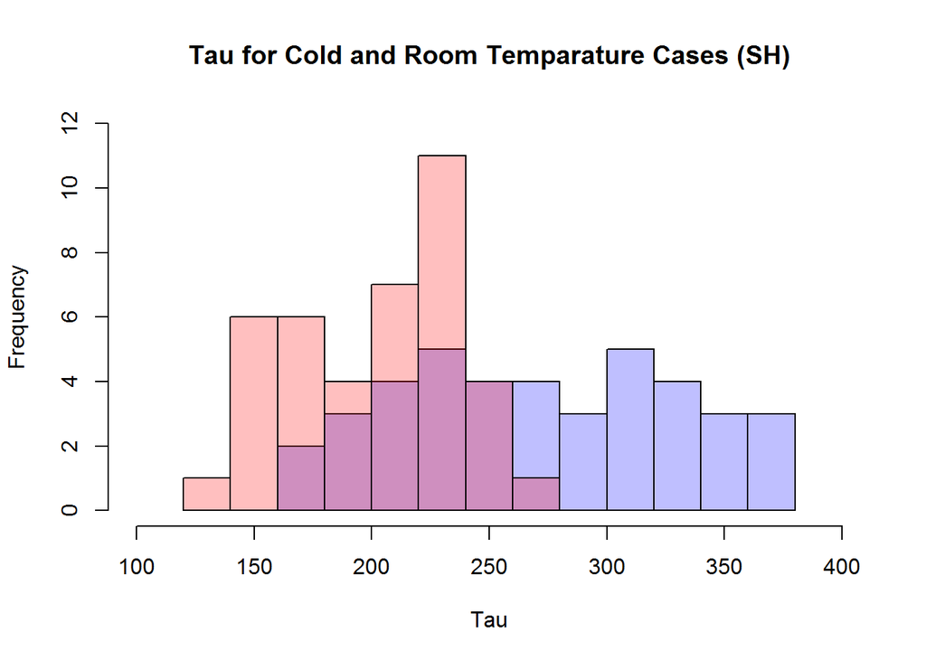

```r
plot(shcold, col=rgb(0,0,1,1/4), xlim=c(100,400), ylim=c(0,12), main="Tau for Cold and Room Temparature Cases (SH)", xlab="Tau", ylab="Frequency")
plot(shrt, col=rgb(1,0,0,1/4), xlim=c(100,400), add = T)
```

- Plot the Tau for 3B.

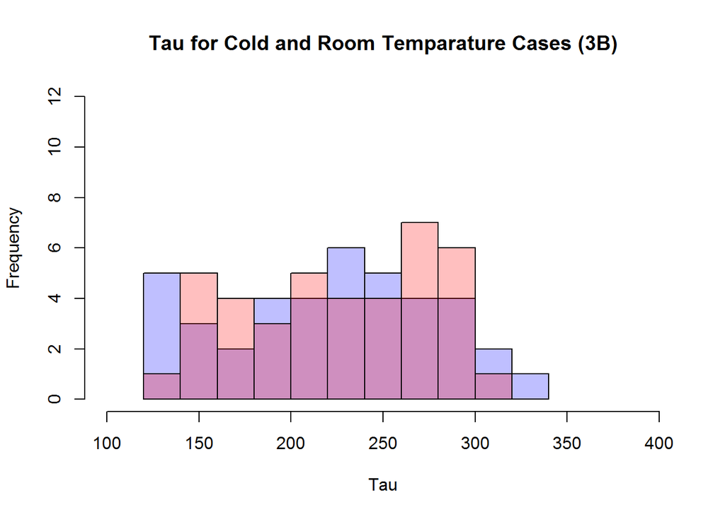

```r
plot(threeBcold, col=rgb(0,0,1,1/4), xlim=c(100,400), ylim=c(0,12), main="Tau for Cold and Room Temparature Cases (3B)", xlab="Tau", ylab="Frequency")
plot(threeBrt, col=rgb(1,0,0,1/4), xlim=c(100,400), add = T)
```

- Check the variance for SH.

```r
var.test(infile[infile$test.case=="SH-COLD",]$tau, infile[infile$test.case=="SH-RT",]$tau)
```

```
##
##  F test to compare two variances
##
## data:  infile[infile$test.case == "SH-COLD", ]$tau and infile[infile$test.case == "SH-RT", ]$tau
## F = 2.646, num df = 39, denom df = 39, p-value = 0.00305
## alternative hypothesis: true ratio of variances is not equal to 1
## 95 percent confidence interval:
##  1.39946 5.00281
## sample estimates:
## ratio of variances
##            2.64598
```

- Check the variance for 3B.

```r
var.test(infile[infile$test.case=="3B-COLD",]$tau, infile[infile$test.case=="3B-RT",]$tau)
```

```
##
##  F test to compare two variances
##
## data:  infile[infile$test.case == "3B-COLD", ]$tau and infile[infile$test.case == "3B-RT", ]$tau
## F = 1.192, num df = 39, denom df = 39, p-value = 0.586
## alternative hypothesis: true ratio of variances is not equal to 1
## 95 percent confidence interval:
##  0.630396 2.253552
## sample estimates:
## ratio of variances
##             1.1919
```

> *In F-test, null hypothesis is ratio of variances equal to 1. Alternate is not equal to 1. So if P-Value is less than $\alpha$ (normally 0.05), then we reject the null hypotheis and we conclude that variance is not equal.* *In our case, for SH we see unqual variance (p-values are low). It is also evident from the above histogram plot. But for 3B we see equal variance (p-values are high). So we can proceed to perform two sample t-test with equal variance for 3B.*

##### **Step 2**: Choose $\alpha$

- Set $\alpha$ = 0.01
- I will reject null, only if there is strong evidence that there is a difference. Because,
  - Risk associated with drawing incorrect conclusions is moderately high, if the brewery making recommendations to their distributors.
  - Business decisions could impact the brewery’s reputation.
  - Cost of collecting new observations is substantial in terms of time and effort (but not money).

```r
alpha = 0.01
```

##### **Step 3**: Calculate t-statistic for equal variance

$$t = \frac{\bar{x_1} - \bar{x_2} - D_0}{SE(\bar{x_1} - \bar{x_2})} \qquad where,\enspace SE(\bar{x_1} - \bar{x_2}) = SD_{pooled} * \sqrt{\frac{1}{n_1} + \frac{1}{n_2}}$$
$$SD_{pooled} = \sqrt{\frac{(n_1 - 1)*s_1^2 + (n_2 - 1)*s_2^2 }{n_1 + n_2 - 2}}$$

Let us calculate first pooled standard deviation,

```r
threeB_cold = infile[infile$test.case=="3B-COLD",]  #Group 1
threeB_rt = infile[infile$test.case=="3B-RT",]      #Group 2

cold_samples = nrow(threeB_cold)  #Nr. of samples in group 1
rt_samples = nrow(threeB_rt)      #Nr. of samples in group 2

cold_sd = sd(threeB_cold$tau)     #Standard deviation of Tau for group 1
rt_sd = sd(threeB_rt$tau)         #Standard deviation of Tau for group 2

sd_pooled_num = (cold_samples - 1)*cold_sd^2 + (rt_samples - 1)*rt_sd^2
sd_pooled_denom = cold_samples + rt_samples - 2

sd_pooled = sqrt(sd_pooled_num / sd_pooled_denom)
```

Now we can calcuate test statistic.

```r
cold_mean = mean(threeB_cold$tau)  #Mean of Tau for group 1
rt_mean = mean(threeB_rt$tau)      #Mean of Tau for group 2

num = cold_mean - rt_mean - 0
denom = sd_pooled * sqrt(1/cold_samples + 1/rt_samples)

t = num / denom                    #Test Statistic
print(t)
```

```
## [1] -0.476223
```

##### **Step 4**: Plot the Sampling Distribution of mean

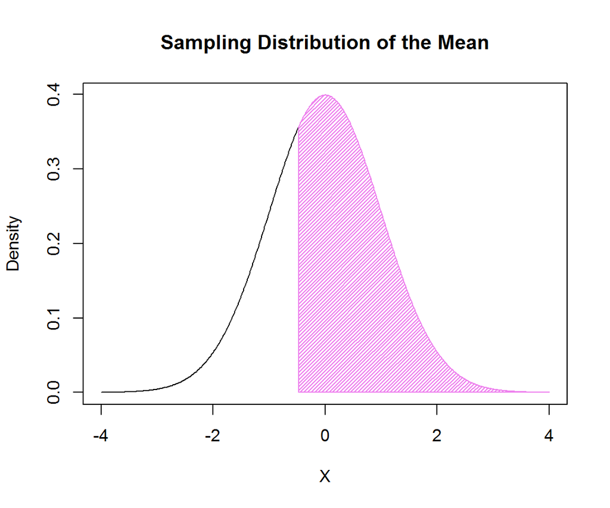

##### **Step 5**: Calculate `P-Value`

> *To calcuate the P-value for t-distribution we need to know the degree of freedom. For Two sampled t-test with equal variance, it can be calculated as,*

$$df = nr.of.samples\ in\ group1 + nr.of.samples\ in\ group2 - 2$$

```r
df = cold_samples + rt_samples - 2
p_value = 1-pt(t, df = df )  #100% of the total area under the t-distribution minus the area to the left of t-statistic.
print(p_value)
```

```
## [1] 0.682377
```

##### **Step 6**: Is the `P-Value` < $\alpha$

```
## [1] "P-Value is not less the alpha, so Fail to Reject the Null Hypothesis !"
```

##### **Step 7**: Confidence Interval

$$Confidence Interval \enspace = \enspace \bar{x} \pm t_{critical} * SE(\bar{x}) \enspace = \enspace \bar{x} \pm t_{critical} * SD_{pooled} * \sqrt{\frac{1}{n_1} + \frac{1}{n_2}}, \enspace SD_{pooled} = \sqrt{\frac{(n_1 - 1)*s_1^2 + (n_2 - 1)*s_2^2 }{n_1 + n_2 - 2}}$$

- Let us first calculate critical value for our chosen $\alpha$ and degree of freedom.

```r
area = 1-(alpha/2)  #Assume alpha as 5%. 100% - 5% = 95%. To calculate 95% interval we need to find the area between (2.5% and 97.5%). So divide alpha/2 and subtract from 1 for arriving the upper limit value 0.975.

t_critical = qt(area, df = df)  #Critical value of t at 97.5%. Since t-distribution is symmetric critical value at 2.5% will be same.

sprintf("Critical value for %s%% confidence interval - One sided test is: %s",(1-alpha)*100, t_critical)
```

```
## [1] "Critical value for 99% confidence interval - One sided test is: 2.64034001529213"
```

- Now we can calcuate our confidence interval.

```r
mean_diff = cold_mean - rt_mean

confidence_lower_limit = mean_diff - (t_critical * sd_pooled * sqrt(1/cold_samples + 1/rt_samples) )

confidence_upper_limit = mean_diff + (t_critical * sd_pooled * sqrt(1/cold_samples + 1/rt_samples) )

sprintf ("%s%% Confidence level of difference of mean between two groups is between %s and %s",(1-alpha)*100, confidence_lower_limit, confidence_upper_limit)
```

```
## [1] "99% Confidence level of difference of mean between two groups is between -37.1096428045155 and 25.7686428045155"
```

## Two Sample t-test - Using R

##### Perform Two Sample One-tail t-test

```r
t.test(threeB_cold$tau, threeB_rt$tau, alternative="greater", var.equal = TRUE, conf.level = 0.99)
```

```
##
##  Two Sample t-test
##
## data:  threeB_cold$tau and threeB_rt$tau
## t = -0.4762, df = 78, p-value = 0.682
## alternative hypothesis: true difference in means is greater than 0
## 99 percent confidence interval:
##  -33.9515      Inf
## sample estimates:
## mean of x mean of y
##   221.189   226.860
```

> *In R, the confidence interval calculation will be different while performing one-tail test in R and not expected as we want. So to know the correct confidence interval, we need to remove the option alternative=“greater” for performing two-tailed test.*

```r
t.test(threeB_cold$tau, threeB_rt$tau, var.equal = TRUE, conf.level = 0.99)
```

```
##
##  Two Sample t-test
##
## data:  threeB_cold$tau and threeB_rt$tau
## t = -0.4762, df = 78, p-value = 0.635
## alternative hypothesis: true difference in means is not equal to 0
## 99 percent confidence interval:
##  -37.1096  25.7686
## sample estimates:
## mean of x mean of y
##   221.189   226.860
```

> *Above is the Confidence Interval which we interested. This is same as we manually calculated. !!*